# Introduction to Unix and the Command Line

*Note: this is a static notebook (ie. not interactive). All exercises and commands in this session will be performed directly in a terminal window. To launch a new terminal, click on `File>New>Terminal`.*

## Hardware, software, and Operating Systems

- harware = laptop, desktop, iphone
- software = word processing, spreadsheet, graphics, games email
- OS (also software) = Windows, Mac, Android, Ubuntu, Debian, Unix, etc

## Computer Structure

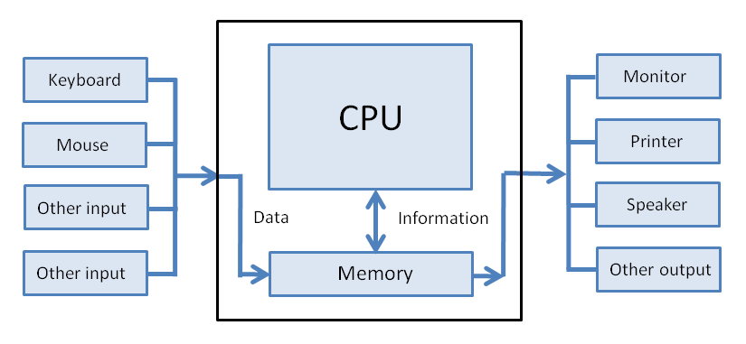

## Interfaces

How we interact with the computer (input and output)

### Graphical User Interface (GUI)

- anything you see and and click (FileExplorer, Finder)

[figure not shown]

### Command Line Interface (CLI)

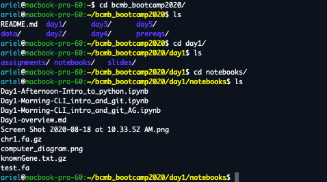

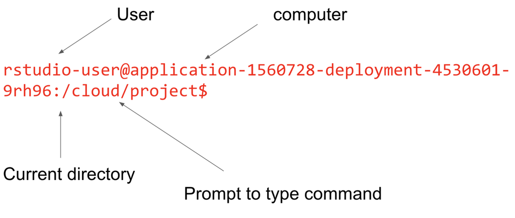

## File System

### Navigating the File System

The first thing we need to figure out is 'where are we' in the file system. To do this, we want to '_*P*_rint the _*W*_orking _*D*_irectory' using the command `pwd`

```python
%%bash
pwd
```

```
/home/timp/bcmb_bootcamp/day1/notebooks
```

We can list the contents of the directory using the built-in program `ls`

```python
%%bash
ls
```

### Wildcards and tab complete

- The * matches one or more occurrence of any character
- The ? matches a single occurrence of any character
- Another shortcut is tab completion, type the beginning of a file or directory, then hit tab for it to automatically fill in the rest

```python
%%bash
ls *.fa
ls te?t.fa
```

#### Options/Input arguments

Bash/shell commands can take input arguments or options. One convention is to use a dash (`-`) to specify arguments. For example, we can ask ls to show a more detailed list of information for each file/folder:

```python
%%bash
ls -l
```

We can aggregate different options by directly appending options one after another. The following shows how to display file sizes in human readable formats (`-h`):

```python
%%bash
ls -lh
```

```python
%%bash
ls ../
```

### Manual Pages (man)

It is certainly not expected that you memorize all arguments for every command. This is where the manual (`man`) comes in handy. You can use `man command_name` to find information about how to use a specific command. For example:

```python
%%bash
man ls
```

Here, man is a command that takes one input argument (which should be a Bash command) and outputs the corresponding manual.

## Creating and Navigating Folders

Now that we have a basic overview of how to interact with the computer in bash, it will be useful to understand how to create folders (directories) and navigate around our system. We've already used the `pwd` command to learn where we currently are. But what if we wanted to make a new directory to contain a project?

The `mkdir` command stands for “make directory”. It takes in a directory name as an *argument*, and then creates a new directory in the current working directory.

```python
%%bash
mkdir myDirectory
```

Nothing seemed to happen? Lets check and see if our new directory was made:

```python
%%bash
ls -l
```

`cd` stands for “change directory”. Just as you would click on a folder in Windows Explorer or Finder on a Mac, `cd` switches you into the directory you specify. In other words, `cd` changes the working directory.

```python
%%bash
cd myDirectory
pwd
```

We can move back into the previous directory by using the shortcut `..`

```python
%%bash
cd ..
pwd
```

And finally, we can remove an (empty) directory using `rmdir`.

```python
%%bash
rmdir myDirectory
ls
```

### Review

- The command line is a text interface for the computer’s operating system. To access the command line, we use the terminal.
- A filesystem organizes a computer’s files and directories into a tree. It starts with the root directory. Each parent directory can contain more child directories and files.
- From the command line, you can navigate through files and folders on your computer
  - `pwd` outputs the name of the current working directory.
  - `ls` lists all files and directories in the working directory.
  - `cd` switches you into the directory you specify.
  - `mkdir` creates a new directory in the working directory.
  - `rmdir` removes an empty directory

## Viewing and changing files

### Creating files

There are several ways to create a file. One of the easiest is to just create an empty file by touching it (`touch`)

```python
%%bash
touch myBrandNewFile.txt
```

```python
%%bash
ls -l
```

Since this file is empty, we should add something to it at this point. We can write directly to a file by *redirecting* some content into the file. This is achieved with the `>`. Imagine that this is an arrow pointing to where you want to put the output. Here we will also introduce you to the `echo` command which simply repeats the first argument. Here we're going to have the output of `echo` *redirected* into our new file.

```python
%%bash
echo 'Hello World' > myBrandNewFile.txt
```

We can now view the contents of a file by using the command `cat`:

```python
%%bash
cat myBrandNewFile.txt

more myBrandNewFile.txt
```

### Moving and removing files

The `mv` command moves files or directories

```python
%%bash
mv myBrandNewFile.txt myOlderFile.txt
ls -l
```

And finally, we can remove a file using the `rm` command. The `rm` command removes files or directories (removed files will be gone forever, proceed with caution):

```python
%%bash
rm myOlderFile.txt
ls -la
```

### File properties

```python
%%bash
du test.fa

du -h test.fa #outputs in 'human-readable' format (byte, kb, mb, etc)
```

Lets see what's actually inside this file

```python
%%bash
more test.fa
```

To count the number of words and lines in your file

```python
%%bash
wc test.fa #words
wc -l test.fa #lines
wc -m test.fa #characters
```

### Downloading files from the internet

```python
%%bash
wget http://sgd-archive.yeastgenome.org/sequence/S288C_reference/chromosomes/fasta/chr01.fsa
```

If we check the directory listing, we should now see a new file `chr01.fsa`

```python
%%bash
ls -la
```

Let's take a quick peek inside. This is a large file so maybe we only want to see the first few lines...

```python
%%bash
head chr01.fsa
```

### File compression/uncompression

Many files and file types can be compressed to save space (e.g. 'zipping' a file). Often times you may have to uncompress a file that you download from the internet before being able to read/use it. Similarly, you may often have to compress a file before uploading or to save disk space. Compression and uncompression are done using programs such as `tar`, and/or `gzip`/`gunzip`.

```python
%%bash

du -h chr01.fsa
gzip chr01.fsa # to compress the file
du -h chr01.fsa.gz
```

```python
%%bash

du -h chr01.fsa.gz
gunzip chr01.fsa.gz # to uncompress the file
du -h chr01.fsa
```

Try it out for yourself!

Use this list of knownGenes from the UCSC Genome Browser - it's already compressed, and it's a larger file so you'll see a big difference using `du -h`

```python
%%bash
wget http://hgdownload.cse.ucsc.edu/goldenpath/hg19/database/knownGene.txt.gz
```

### Practice Exercise

Download this file containing the genome sequence of E. coli K12 using `wget` command: https://github.com/doxeylab/learn-genomics-in-unix/raw/master/task1/e-coli-k12-genome.fasta.gz

1. What is the size of this compressed file in megabytes?
2. Uncompress the file. What is the size now in megabytes?
3. How many lines are in the uncompressed file?

## Viewing files

More Command:

- Shows only one page at a time, space bar to advance
- Can't go back up
- q will stop it

```python
%%bash
more chr01.fsa
```

Less Commmand:

- use up and down arrows to scroll
- spacebar scrolls down
- hit q to quit

```python
less chr01.fsa
```

The head command lets you look at just the first few lines of a file. By default, it shows the first 10 lines of a file:

```python
%%bash
head chr01.fsa
```

The default is changable with -n flag as shown below:

```python
%%bash
# Print the first 20 lines of your file
head -n 20 chr01.fsa
```

The tail command is the same, but for the "tail-end" of your file instead:

```python
%%bash
tail chr01.fsa
```

## Searching in files

### pattern finding with grep

A common task in programming is to search for a string within a file. `grep` is a powerful command for searching. `grep` takes a search string or regular expression as its first argument and a set of target files as its second. With only these arguments, `grep` will search the file and return lines containing the search string.

```python
%%bash
grep "TACCCTACC" chr01.fsa
```

If you add the `-c` argument then `grep` returns the number of lines with the search string

```python
%%bash
grep -c "TACCCTACC" chr01.fsa
```

## Piping/redirection

### Output Redirection

The '>' redirects the output of the commands on the left of it to a file specified on the right - we used this before for echo to make a file:

```python
%%bash
tail -n 30 chr01.fsa > tail.txt
```

### Input Redirection

Similarly, the '<' redirects input from a file to be used by the command on the left

```python
%%bash
sort < tail.txt
```

### Chaining commands

You can use the pipe operator `|` to chain together many different commands. Essentially taking the output of one command and using that is the input for the next one in the chain.

```python
%%bash
grep "TACCCTACC" chr01.fsa | wc -l
# will count the number of lines containing the word "word"
# or alternatively
cat chr01.fsa | grep "TACCCTACC" | wc -l  # does the same thing as above
```

This can be used to string together commands to streamline workflows. we will spend some more time on this later.

## Practice Exercises

1. Chain together two commands to print out lines 5-10 of chr01.fsa
2. How many characters are in chr01.fsa?
3. How many lines are in the file?
4. How many lines in the file contain the word “ATATATAT”?
5. How many times does the word “ATATATAT” occur in the file? Hint: -o
6. What character (A, C, G, or T) is most common in tail.txt?

# Resources

- Cheat sheet containing many useful *nix commands:
  - https://files.fosswire.com/2007/08/fwunixref.pdf